# Cyclistic Case study

by Alexander Fastner

2023-02-19

# Analysis of Cyclistic Data 2022

[figure not shown]

Cyclistic is a (fictional) bike-share company in Chicago that wants to convert casual users to subscribing members.

## Buisness Task

What is the best value offering Cyclistic can provide its existing customers to upsell them to an annual model resulting in a revenue increase.

## Plan

- We want to convince casual users to buy memberships
- To advertise most effectivly we want to find casual users who exhibit similar patterns to existing members
- Then we need to identify the best place/time to market to these users.

## Dataset

The dataset is provided by Lyft Bikes and Scooters, LLC under this license agreement https://ride.divvybikes.com/data-license-agreement which allows the non-commercial use of this data in scope of this project. The data used and analyzed is not personally identifiable and is not tied to specific users. It is a dataset created for a fictional company, but the data is owned by the city of Chicago and is from a reliable government source. It is a primary data source, and as described in the prompt can be considered comprehensive for the scope of this project. The dataset is updated monthly and contains data back to 2013. The data format is not consistent and some data cleaning/ management needed to be done before analysis.

## Data Loading

### Import Libraries

```r
library(ggplot2)
library(tidyverse)
library(lubridate)
library(magrittr)
library(dplyr)
library(data.table)
library(scales)
library(viridis)
```

## Data Cleaning

There are some issues with the data that need to be addressed before analysis.

- remove rows with NA’s in the following columns
  - start_station_name
  - start_station_id
  - end_station_name
  - end_station_id
- remove any rides with negative ride lengths
- filter out any rides over 24 hours
- change relevant date format to correct type for following plots :Hour, Day, Month

## Analysis

**We want to answer the following**

1. Distinguish usage patterns between casual users and members
2. Best time to market  
   - most effective time of day to market  
   - most effective Weekday to market  
   - most effective Month to market
3. Most effective area to market  
   - most common starting location  
   - most common destinations

**Most members make shorter trips!**

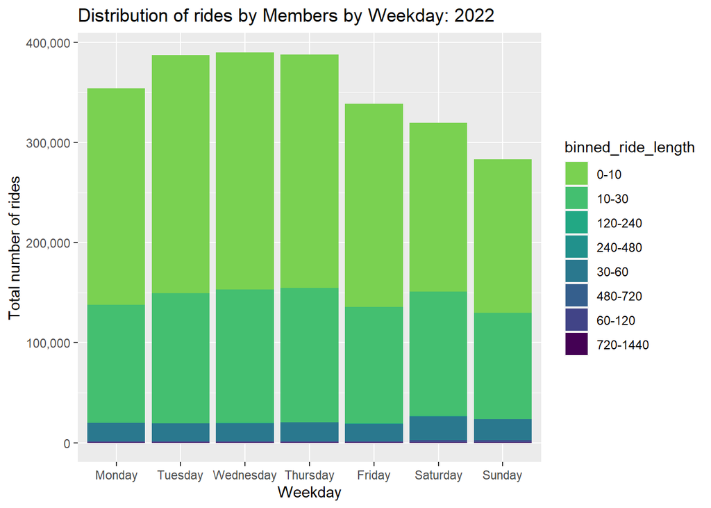

Most members travel less than 30 min regardless of day.

**Members travel during the workweek**

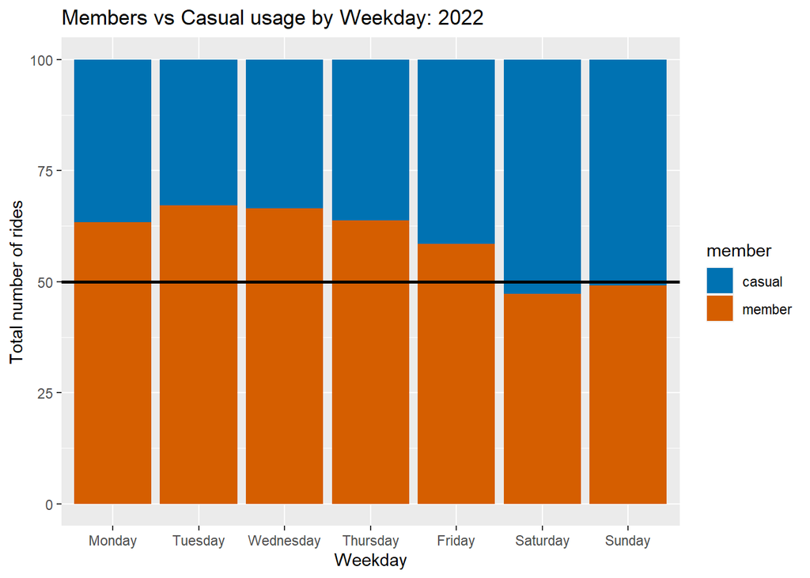

Members are more likely to ride during the week probably to or from work. Whereas non members are more likely to ride on the weekends for leisure.

**Most active time is in the early afternoon around 2**

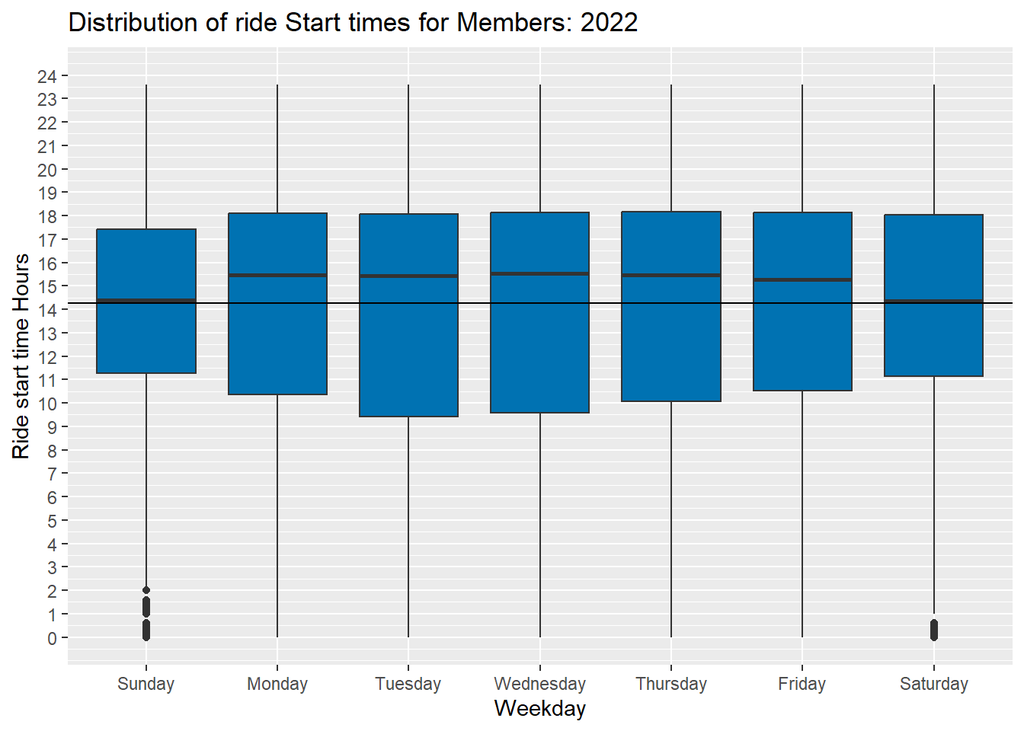

The mean ride start time is around 2pm which makes sense, as most trips will occur going to or from work. The boxplot above shows that the majority of rides start somewhere between 10-6.

**Most active months are May-Oct!**

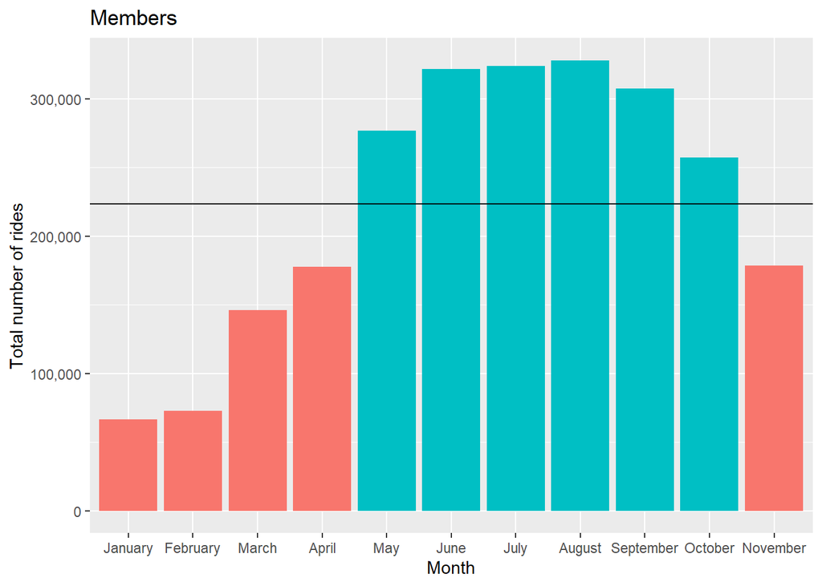

The most active months for members are in the summer between May and October. Given the temperatures in Chicago, where Cyclistic is based this is what we would expect.

**Most popular starting locations**

| Kingsbury St & Kinzie St | 22080 |
| --- | --- |
| Clark St & Elm St | 19302 |
| Wells St & Concord Ln | 18661 |

**Most popular Destiations**

| Kingsbury St & Kinzie St | 21744 |
| --- | --- |
| Clark St & Elm St | 19667 |
| Wells St & Concord Ln | 19198 |

## Conclusion

### Goal

We want to convert casual users to members

### Recap of the Plan

The plan was to identify casual users with similar habits and usage patterns to members as these would be the most likely to upgrade to a member plan. We looked for the following information:

- Differences in usage between casual users and members
- best time to market
  - most effective time of day to market
  - most effective Weekday to market
  - most effective Month to market
- most effective area to market
  - most common starting location
  - most common destination

## Appendix

The following analyses and visualizations were also made in exploring the data.

**Visualizations**

1. - ride duration breakdown under 24 hours
   - ride duration breakdown under 2 hours
   - ride duration breakdown under 1 hour
2. - ride start time by hour
   - ride count Weekday
   - ride count by Weekday with ride length as factor
   - compare member vs. casual ride count by Weekday with ride length as factor
   - ride count Month
   - ride count by Month with membership as factor
3. - most popular starting locations
   - most common destination

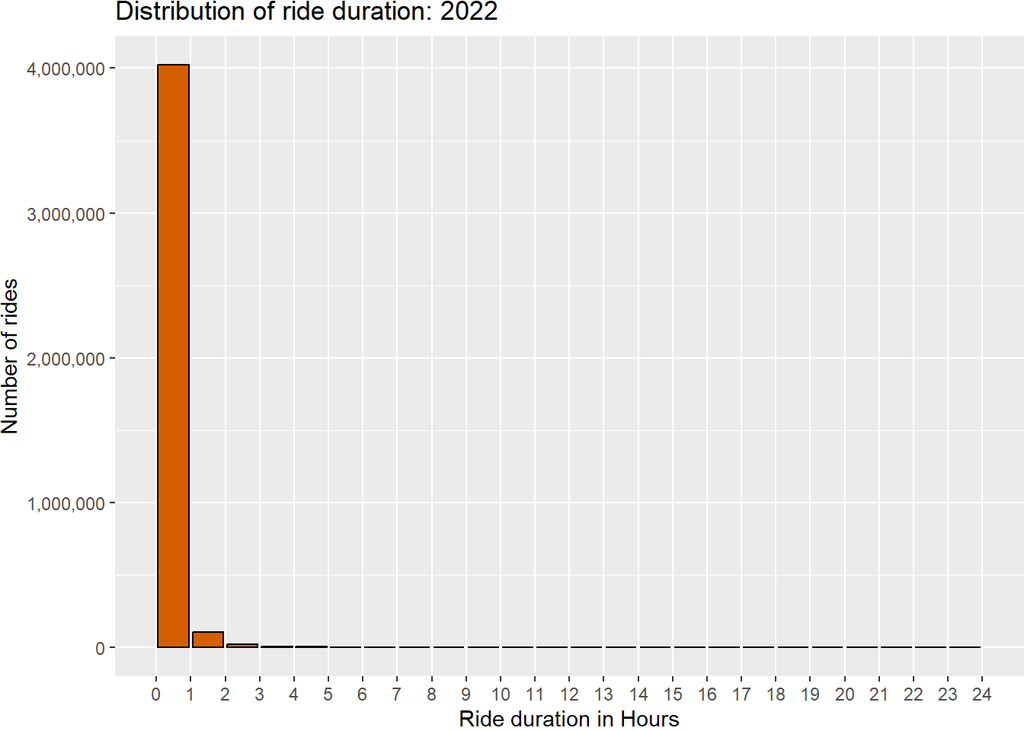

Here we can see that the vast majority of all trips are very short.

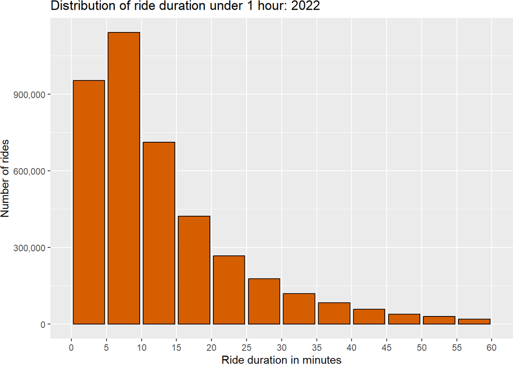

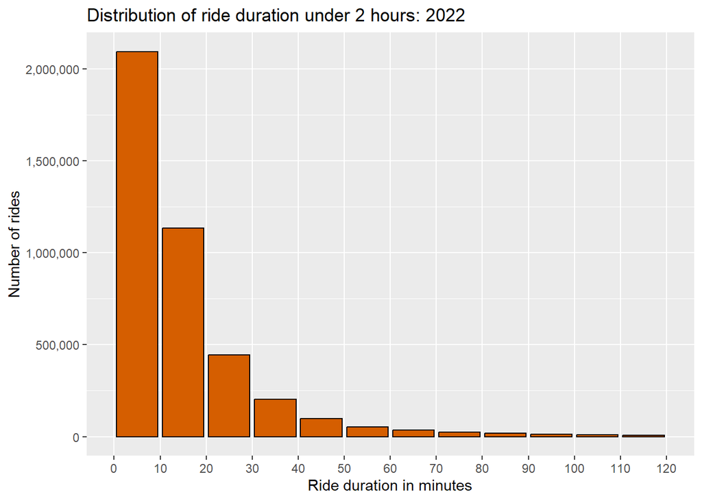

Most fall under 60 min

### Distribution of ride start times

### Distribution of ride start times for Members

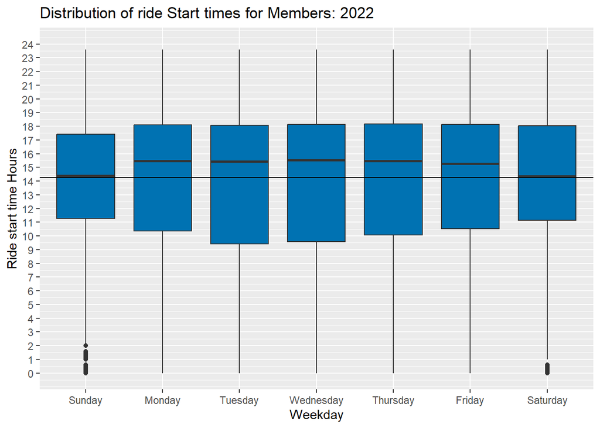

### Distribution of ride start times for Casual Users

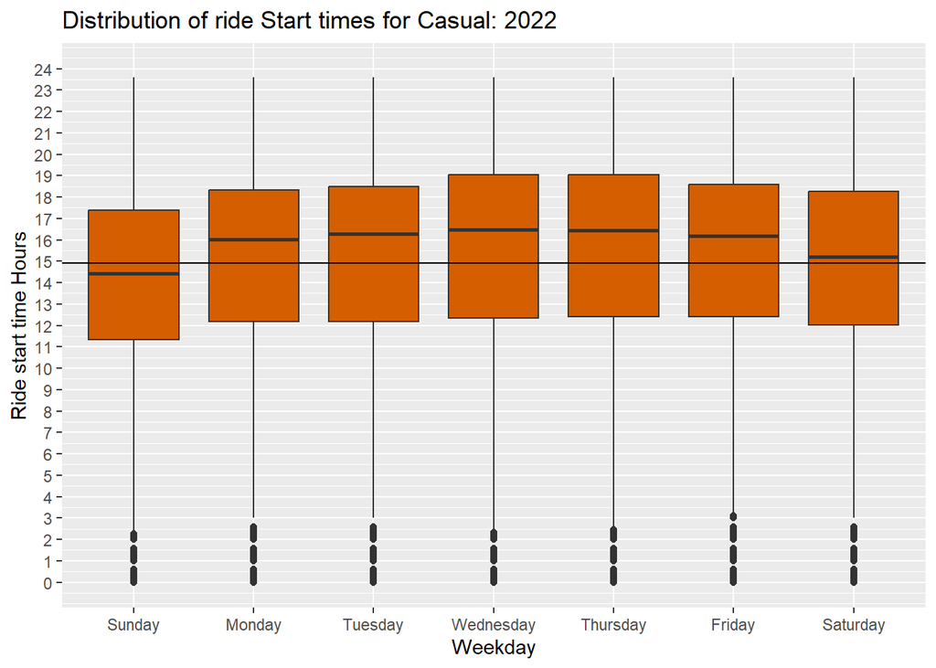

### Analyze rides by Weekday

[figure not shown]

### Ride length Breakdown for Members vs. Casual Users

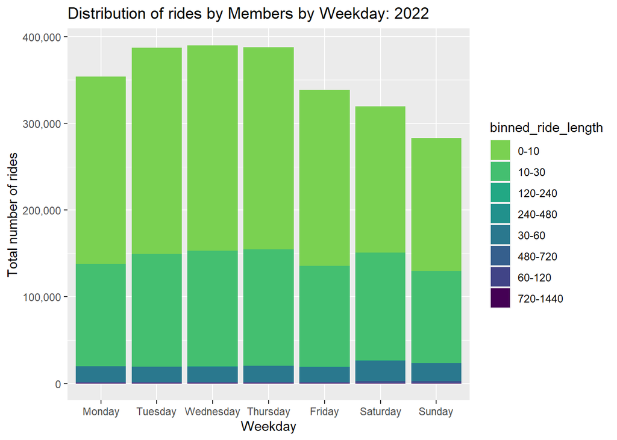

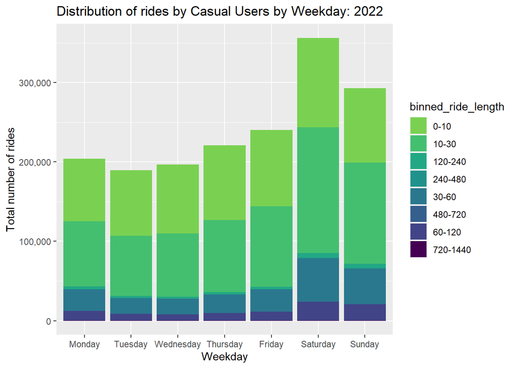

### Comparative daily usage

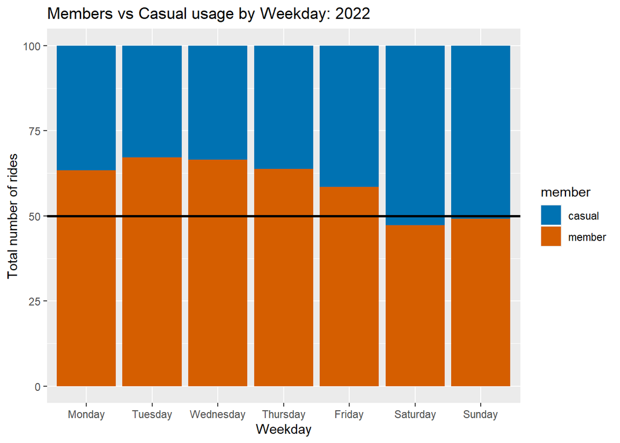

### Analysis of Monthly usage

Distribution of rides by Month for Casual Users / Members

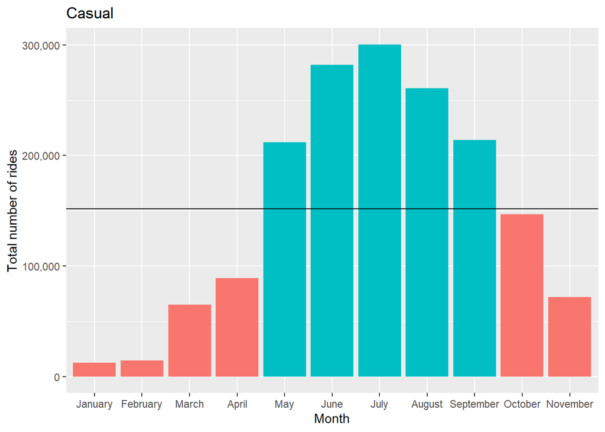

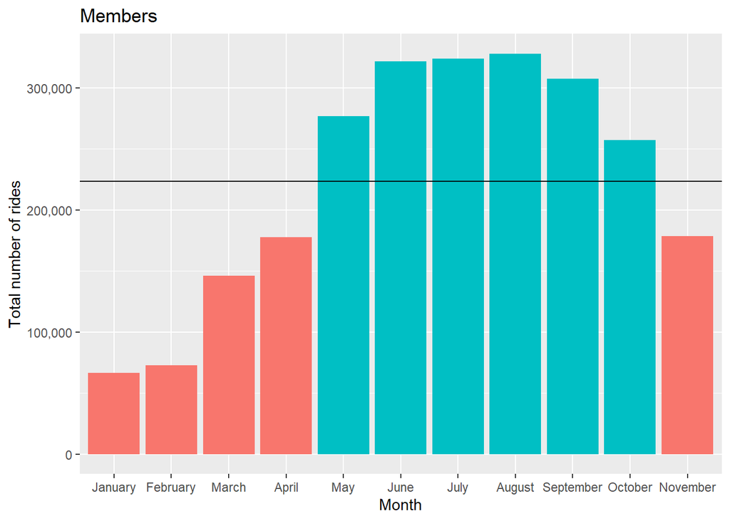

Most popular starting locations

| Streeter Dr & Grand Ave | 69292 |
| --- | --- |
| DuSable Lake Shore Dr & Monroe St | 38164 |
| DuSable Lake Shore Dr & North Blvd | 36873 |
| Michigan Ave & Oak St | 36266 |
| Wells St & Concord Ln | 33111 |
| Millennium Park | 31681 |
| Clark St & Elm St | 30906 |
| Theater on the Lake | 30660 |
| Kingsbury St & Kinzie St | 29844 |
| Wells St & Elm St | 27651 |

Most popular Destinations

| Streeter Dr & Grand Ave | 70550 |
| --- | --- |
| DuSable Lake Shore Dr & North Blvd | 39752 |
| DuSable Lake Shore Dr & Monroe St | 37444 |
| Michigan Ave & Oak St | 37280 |
| Wells St & Concord Ln | 33231 |
| Millennium Park | 32470 |
| Theater on the Lake | 31054 |
| Clark St & Elm St | 30635 |
| Kingsbury St & Kinzie St | 28683 |
| Wells St & Elm St | 27003 |